# FacultyTenure

Linli Zhou

2022-09-03

```r
data<-read_excel("/Users/linlizhou/Documents/LASELL/Faculty Data for Analyst Candidates.xlsx")
```

```r
theme_lz <- function(){
    font <- "Helvetica"   #assign font family up front
    theme_minimal() %+replace%    #replace elements already strips axis lines,
    theme(
      panel.grid.major = element_blank(),    #strip major gridlines
      panel.grid.minor = element_blank(),    #strip minor gridlines
      plot.title = element_text(family = font, size = 9, face = 'bold',hjust = 0.5, vjust = 2),
      axis.title = element_text(family = font, size = 9),
      axis.text = element_text(family = font, size = 9),
      axis.text.x = element_text(family = font, size = 9, margin = margin(t=5,b=10)),
      axis.ticks = element_blank(),          #strip axis ticks
      axis.text.y=element_blank(),
      legend.title = element_text(family = font, size=9),
      legend.text = element_text(family = font, size=7),
      legend.position="right",

      strip.text = element_text(family = font, size = 9, margin = margin(t=5,b=10)),#move up is + 1
      strip.background = element_blank()
    )}
mycolors<-c("#13294b","#5c88da","#69b3e7","#da291c","#641F45","#fcb53b","#6C6F70")#1-3blue,4-5red,6yellow,7grey
```

# Research questions

- Who/what job titles are those tenured/non tenured
- Prt of each job title that tenured = tenured in job1/ all people in job1
- T/NT prt (out of all T/NT total in each year) by year
- T/NT prt (out of all T/NT total in each department) by department
- Gender equity: female tenured/ all female vs male
- Gender equity by department: in department 1, calcualte male-female prt gap, then rank
- Racial equity: tenured in race1/ all people in race1
- Gender equity by department: in department 1, calcualte white-black prt gap, then rank

```r
#remove duplicated rows
data<-unique(data)#from 4003 to 3984 observations
#remove duplicated ID/persons
unique(data$ID)%>%length()#1147 unique ID
```

```
## [1] 1147
```

```r
data%>% group_by(ID) %>% summarise(cnt=n()) %>%arrange(-cnt) %>%filter(cnt>1) #815 duplicated IDs
```

```
## # A tibble: 815 × 2
##          ID   cnt
##       <dbl> <int>
##  1 30681890     9
##  2 30091031     7
##  3 30091098     7
##  4 30137721     7
##  5 30137726     7
##  6 30137850     7
##  7 30137920     7
##  8 30137932     7
##  9 30137989     7
## 10 30138133     7
## # … with 805 more rows
```

Tenured percentage has been increased since 2016 from 40% to 44% in 2021, with 2020 being the highest 45%. Non-tenured faculty percentage has been decreased from 60% to 56%, with 2020 being the lowest 55%. There are still 12% less tenured faculty than non tenured.

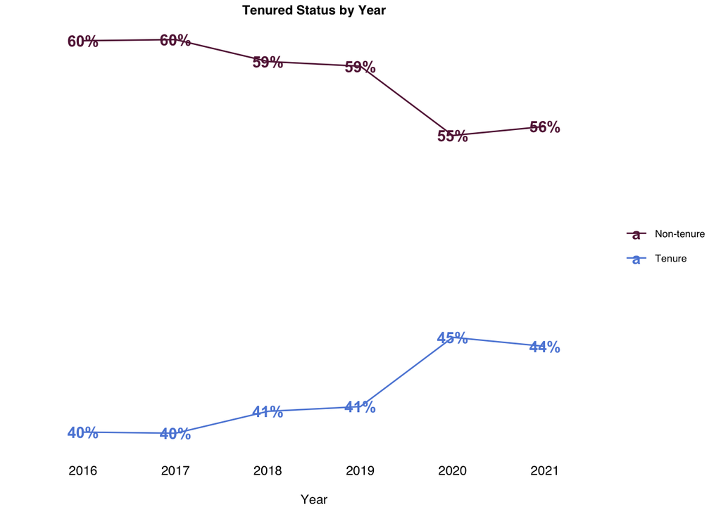

```r
data%>%group_by(Year, `Tenure Status`)%>%
  summarise(cnt=n_distinct(ID))%>%mutate(prt=percent(cnt/sum(cnt),digits=0))%>%
  ggplot(aes(color=factor(`Tenure Status`),x=factor(Year),y=prt,group=factor(`Tenure Status`)))+geom_line()+
  geom_text(aes(label=prt),fontface="bold")+
  theme_lz()+
  scale_y_continuous(breaks = seq(.4,.6,by=.05),labels = scales::percent)+
  labs(title="Tenured Status by Year",x="Year",y="")+
   scale_color_manual(values = c(mycolors[5],mycolors[2]),labels=c("Non-tenure","Tenure"),name="")+
  theme(axis.text.y=element_blank())
```

```r
#scale_color_manual(values = c("Non-tenure"=mycolors[4],"Tenure"=mycolors[1]),name="")
#geom_bar(stat = "identity", position=position_dodge())
```

Assistant Professor has 64% Tenured status, 4% higher than Professor and 6% higher than Associate Professor.

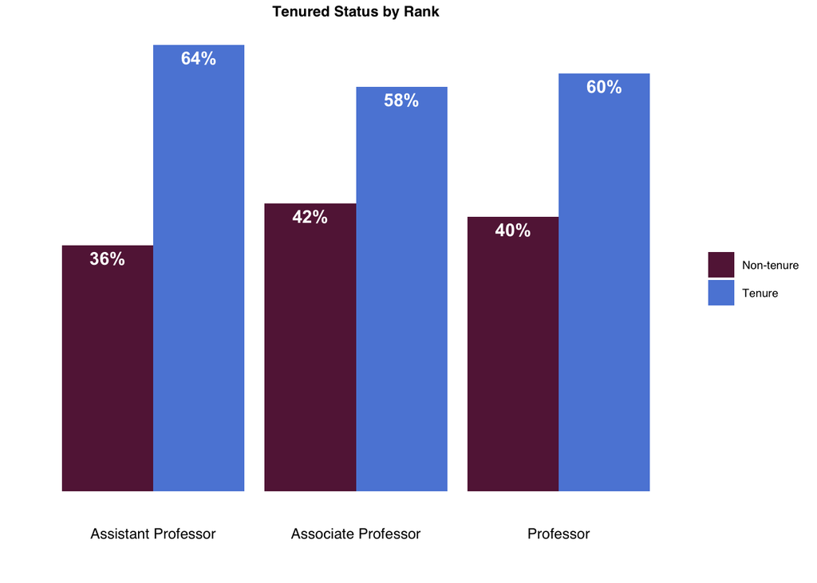

```r
data%>% filter(Rank=="Professor"|Rank=="Assistant Professor"| Rank=="Associate Professor")%>%
  group_by(Rank,`Tenure Status`)%>%summarise(cnt=n_distinct(ID))%>%mutate(prt=percent(cnt/sum(cnt),digits=0))%>%
ggplot(aes(fill=factor(`Tenure Status`),x=factor(Rank),y=prt))+
  geom_bar(stat = "identity",position = position_dodge())+
  geom_text(aes(label=prt),position=position_dodge(.9),vjust=1.5,color="white",fontface="bold")+theme_lz()+
  scale_fill_manual(values=c(mycolors[5],mycolors[2]),labels=c("Non-tenure","Tenure"),name="")+
  labs(x="",y="",title="Tenured Status by Rank")
```

```r
#make department count as ndep
ndep<-data%>%group_by(Department)%>%summarise(cnt=n_distinct(ID))%>%arrange(-cnt)#
#four groups based on department count
ndep[ndep$cnt>30,]%>%str() #11 large departments
ndep[ndep$cnt%in%seq(11,30,by=1),]%>%str()#22 medium departments
ndep[ndep$cnt%in%seq(2,10,by=1),]%>%str()#12 small departments
ndep[ndep$cnt==1,]%>%str()#7 tiny departments

#order based on tenure prt
dep.order<-data%>%group_by(Department,`Tenure Status`)%>%
  summarise(cnt=n_distinct(ID))%>%mutate(prt=percent(cnt/sum(cnt),digits = 0))%>%
  filter(`Tenure Status`=="Tenure Line")%>%arrange(-prt)%>%
  mutate(dep.f=factor(Department))
```

```r
#first group n>30, 11 large departments
data%>%filter(Department %in% ndep[ndep$cnt>30,1]$Department ) %>%
  group_by(Department,`Tenure Status`)%>%
  summarise(cnt=n_distinct(ID))%>%mutate(prt=percent(cnt/sum(cnt),digits = 0))%>%
  ggplot(aes(x=Department,y=prt,fill=`Tenure Status`))+geom_bar(stat = "identity")+
  scale_x_discrete(limits = dep.order$dep.f[dep.order$dep.f %in% ndep[ndep$cnt>30,1]$Department])+
  theme_lz()
```

[figure not shown]